# Abstract

In this report, the application of different methods for the construction of portfolios is carried out. The core of these methods is the identification of a simple and concise basis that embraces the capital market line. It demonstrates how portfolio performance and volatility can be estimated from the covariance matrix and annualized rates of return. In addition, through simulations, the efficient frontier of assets is defined (also known as ‘hyperball’), the different weights of assets are identified as their returns and volatilities under the traditional and risk-parity methods. Additionally, the neutral beta on variable income shares is evaluated.

# Efficient Frontier from Modern Portfolio Theory implemented in Python

## Modern Portfolio Theory

Modern Portfolio Theory (MPT) is an investment theory developed by Harry Markowitz and published under the title "Portfolio Selection" in the Journal of Finance in 1952.

Famously related to the acronym for "There Ain't No Such Thing As A Free Lunch". This concept is also closely related to 'risk-return trade-off':

- Higher risk is associated with greater probability of higher return
- Lower risk is associated with a greater probability of smaller return.

MPT assumes that investors are risk-averse, meaning that given two portfolios that offer the same expected return, investors will prefer the less risky one. Thus, an investor will take on increased risk only if compensated by higher expected returns.

Another factor comes in to play in MPT is "diversification". Modern portfolio theory says that it is not enough to look at the expected risk and return of one particular stock. By investing in more than one stock, an investor can reap the benefits of diversification – chief among them, a reduction in the riskiness of the portfolio.

What you need to understand is "risk of a portfolio is not equal to average/weighted-average of individual stocks in the portfolio". In terms of return, yes it is the average/weighted average of individual stock's returns, but that's not the case for risk. The risk is about how volatile the asset is, if you have more than one stock in your portfolio, then you have to take count of how these stocks movement correlates with each other. The beauty of diversification is that you can even get lower risk than a stock with the lowest risk in your portfolio, by optimising the allocation.

## Libraries

```python
import pandas as pd
import numpy as np
import matplotlib.pyplot as plt
import seaborn as sns
import quandl
import scipy.optimize as sco
import scipy.stats as scs
import edhec_risk_kit_206 as erk
from statsmodels import regression
import statsmodels.api as sm

plt.style.use('fivethirtyeight')
np.random.seed(777)

%matplotlib inline
%config InlineBackend.figure_format = 'retina'
import warnings

plt.style.use('seaborn')
warnings.simplefilter(action='ignore', category=FutureWarning)
```

```python
def risk_contribution(w,cov):
    """
    Compute the contributions to risk of the constituents of a portfolio, given a set of portfolio weights and a covariance matrix
    """
    total_portfolio_var = erk.portfolio_vol(w,cov)**2
    # Marginal contribution of each constituent
    marginal_contrib = cov@w
    risk_contrib = np.multiply(marginal_contrib,w.T)/total_portfolio_var
    return risk_contrib

def to_percent(x):
    try: f_string = '{:.2%}'.format(x)
    except: f_string = x
    return f_string

def to_decimal(x):
    try:
        if x >= 100:
            f_string = '{0:,.0f}'.format(x)
        elif x >= 10:
            f_string = '{0:,.1f}'.format(x)
        else:
            f_string = '{0:,.2f}'.format(x)

    except: f_string = x
    return f_string

def annual_volatility(df_single_returns):
    """
    Determines the annual volatility of a strategy.

    Parameters
    ----------
    df_single_returns : pd.Series or np.ndarray
        Periodic returns of the strategy, noncumulative.

    Returns
    -------
    float, np.ndarray
        Annual volatility.
    """

    if len(df_single_returns) < 2:
        return np.nan

    std = df_single_returns.std(ddof=1)

    volatility = std * (252 ** (1.0 / 2))

    return volatility.astype(np.float)
def var_pct(df_single_returns):
    """
    Determines the annual var of a strategy.



    Parameters
    ----------
    df_single_returns : pd.Series or np.ndarray
        Periodic returns of the strategy, noncumulative.



    Returns
    -------
    float, np.ndarray
        Annual var (%).
    """



    if len(df_single_returns) < 2:
        return np.nan



    std = df_single_returns.std(ddof=1)
    vol = std * (252 ** (1.0 / 2))
    t=252
    ci=0.95


    var =  vol*scs.norm.cdf(scs.norm.ppf(1-ci))/np.sqrt(t) #scs.norm.ppf(1-ci, mean, vol) * np.sqrt(t)
    return var.astype(np.float)

def max_drawdown(df_returns):
    max_dd = (np.cumprod(1+df_returns)/np.maximum.accumulate(np.cumprod(1+df_returns))-1).min()
    return max_dd

def cal_max_dd(df_single_return):
    """
    Determines the maximum drawdown of a strategy.

    Parameters
    ----------
    df_single_return :
        Daily returns of the strategy, noncumulative.

    Returns
    ----------
    float
        Maximum drawdown.
    """
    if len(df_single_return) < 1:
        return np.nan

    df_perform_equity_curve = (1. + df_single_return).cumprod()
    df_perform_cum_max = df_perform_equity_curve.cummax()
    # drawdown series
    df_perform_drawdown = df_perform_equity_curve / df_perform_cum_max - 1
    max_dd = df_perform_drawdown.min()
    return max_dd

def annual_return(df_single_return, period):
    """Determines the mean annual growth rate of returns.

    Parameters
    ----------
    df_single_return : pd.Series or np.ndarray
        Periodic returns of the strategy, noncumulative.
    period : str, optional
        Defines the periodicity of the 'returns' data for purposes of
        annualizing. Value ignored if `annualization` parameter is specified.
        Defaults are:
            'monthly':12
            'weekly': 52
            'daily': 252

    Returns
    -------
    float
    """

    if len(df_single_return) < 1:
        return np.nan

    num_years = float(len(df_single_return)) / period

    # Pass array to ensure index -1 looks up successfully.
    df_cum = (df_single_return + 1).cumprod(axis=0) - 1
    f_annual_return = (1. + df_cum.iloc[-1,:]) ** (1. / num_years) - 1

    return f_annual_return.apply(to_percent)

def to_summary(df_returns):
    # Daily return calcs
    df_summary = pd.DataFrame(columns=df_returns.columns)
    df_summary.loc['Summary Stats:'] = ''
    MOIC = np.prod(1+df_returns)
    CAGR = MOIC**(periodicity/len(df_returns))-1
    df_summary.loc['Annualized Return'] = annual_return(df_returns, 252)
    df_summary.loc['Sharpe'] = CAGR/(np.std(df_returns)*np.sqrt(periodicity))
    df_summary.loc['Volatility'] = annual_volatility(df_returns)
    df_summary.loc['VaR'] = var_pct(df_returns).apply(to_percent)

    df_summary.loc['Sortino'] = CAGR/(np.std(np.clip(df_returns, a_max=0, a_min=None))*np.sqrt(periodicity))
    df_summary.loc['Max Drawdown'] = cal_max_dd(df_returns).apply(to_percent)

    df_summary = df_summary.applymap(to_decimal)

    # Monthly return calcs
    df_summary.loc['Monthly Perf. Metrics:'] = ''
    df_months = pd.DataFrame(columns=df_returns.columns)
    df_returnsM = (1+df_returns).resample('M').prod()-1
    MOIC_M = np.prod(1+df_returnsM)
    CAGR_M = MOIC_M**(12/len(df_returnsM))-1
    df_months.loc['Sharpe'] = CAGR_M/(np.std(df_returnsM)*np.sqrt(12))
    df_months.loc['Sortino'] = CAGR_M/(np.std(np.clip(df_returnsM, a_max=0, a_min=None))*np.sqrt(12))

    if len(df_returnsM) >= 36: df_months.loc['Calmar'] = -(np.prod(1+df_returnsM.iloc[-12*3:])**(1/3)-1)\
                                                         / max_drawdown(df_returnsM.iloc[-12*3:])

    df_months = df_months.applymap(to_decimal)
    df_summary = df_summary.append(df_months)

    # Annuals
    df_summary.loc['Annual Returns:'] = ''
    df_annuals = df_returns.groupby(df_returns.index.year).apply(lambda x: np.prod(1+x)-1).applymap(to_percent)
    df_summary = df_summary.append(df_annuals)

    # Drawdowns
    df_summary.loc['Annual Max DD:'] = ''
    df_maxdd = df_returns.groupby(df_returns.index.year).apply(cal_max_dd).applymap(to_percent)
    df_summary = df_summary.append(df_maxdd)
    return df_summary
```

## Yahoo API

```python
import yfinance as yf
from yahoofinancials import YahooFinancials
import matplotlib.pyplot as plt
import warnings
```

### Downloading the stock prices using yahoofinancials

### One stock

```python
yahoo_financials = YahooFinancials('TSLA')

data = yahoo_financials.get_historical_price_data(start_date='2000-01-01',
                                                  end_date='2019-12-31',
                                                  time_interval='weekly')

tsla_df = pd.DataFrame(data['TSLA']['prices'])
tsla_df = tsla_df.drop('date', axis=1).set_index('formatted_date')
tsla_df.head()
```

| formatted_date | high | low | open | close | volume | adjclose |
| --- | --- | --- | --- | --- | --- | --- |
| 2010-06-28 | 30.42 | 17.540001 | 19.000000 | 19.200001 | 49312000 | 19.200001 |
| 2010-07-05 | 20.00 | 14.980000 | 20.000000 | 17.400000 | 25550600 | 17.400000 |
| 2010-07-12 | 21.50 | 16.900000 | 17.950001 | 20.639999 | 15438900 | 20.639999 |
| 2010-07-19 | 22.25 | 19.500000 | 21.370001 | 21.290001 | 7175700 | 21.290001 |
| 2010-07-26 | 21.50 | 19.549999 | 21.500000 | 19.940001 | 3052000 | 19.940001 |

```python
yahoo_financials.get_stock_quote_type_data()
```

```
{'TSLA': None}
```

```python
yahoo_financials.get_key_statistics_data()
```

```
{'TSLA': None}
```

```python
yahoo_financials.get_summary_data()
```

```
{'TSLA': None}
```

```python
yahoo_financials.get_stock_earnings_data()
```

```
{'TSLA': None}
```

### Multiple Stocks

https://finance.yahoo.com/screener

```python
# CHOOSE ASSETS
assets = ['ES=F', 'CL=F','^VIX', 'GC=F']


yahoo_financials = YahooFinancials(assets)

# ADJUST DATE
data = yahoo_financials.get_historical_price_data(start_date='2005-04-23',
                                                  end_date='2020-05-06',
                                                  time_interval='DAILY')

prices_df = pd.DataFrame({
    a: {x['formatted_date']: x['adjclose'] for x in data[a]['prices']} for a in assets
})
```

```python
# prices_df = prices_df.dropna(thresh=1)
```

```python
df = prices_df
df.head()
```

|  | ES=F | CL=F | ^VIX | GC=F |
| --- | --- | --- | --- | --- |
| 2005-04-25 | 1164.00 | 54.570000 | 14.620000 | 434.600006 |
| 2005-04-26 | 1153.75 | 54.200001 | 14.910000 | 437.899994 |
| 2005-04-27 | 1157.25 | 51.610001 | 14.870000 | 433.000000 |
| 2005-04-28 | 1143.00 | 51.770000 | 16.860001 | NaN |
| 2005-04-29 | 1158.50 | 49.720001 | 15.310000 | 435.000000 |

#### Visualization

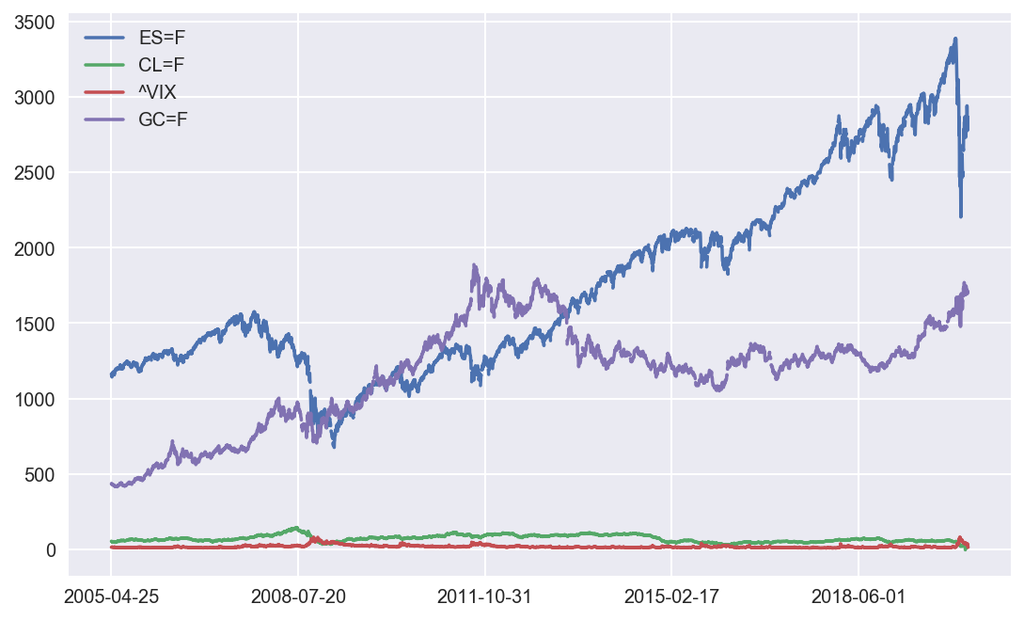

```python
df.plot()
```

## Quandl

https://www.quandl.com/search?filters=%5B%22Free%22%5D

```python
# quandl.ApiConfig.api_key = '2NzhhKfWhxSv2gaWEtks'
# stocks = ['AAPL','AMZN','GOOGL','FB']
# data = quandl.get_table('WIKI/PRICES', ticker = stocks,
#                         qopts = { 'columns': ['date', 'ticker', 'adj_close'] },
#                         date = { 'gte': '2005-1-1', 'lte': '2020-04-30' }, paginate=True)
# data.head()
```

By looking at the info() of data, check if "date" column is already in datetime format.

```python
# data.info()
```

```python
# df = data.set_index('date')
# df.head()
```

```python
# table = df.pivot(columns='ticker')
# # By specifying col[1] in below list comprehension
# # You can select the stock names under multi-level column
# table.columns = [col[1] for col in table.columns]
# table.head()
```

```python
# type(table)
```

```python
# plt.figure(figsize=(14, 7))
# for c in table.columns.values:
#     plt.plot(table.index, table[c], lw=3, alpha=0.8,label=c)
# plt.legend(loc='upper left', fontsize=12)
# plt.ylabel('price in $');
```

## Returns

```python
returns = df.pct_change()
```

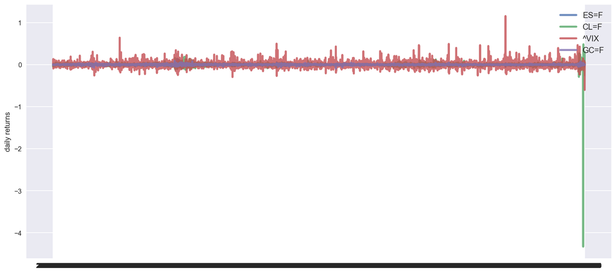

```python
plt.figure(figsize=(14, 7))
for c in returns.columns.values:
    plt.plot(returns.index, returns[c], lw=3, alpha=0.8,label=c)
plt.legend(loc='upper right', fontsize=12)
plt.ylabel('daily returns')
```

Volatility, positive and negative spike returns can be seen in this plot.

```python
lookback = 21*6
corr_lookback = 21*24
periodicity = 252
```

```python
returns
```

|  | ES=F | CL=F | ^VIX | GC=F |
| --- | --- | --- | --- | --- |
| 2005-04-25 | NaN | NaN | NaN | NaN |
| 2005-04-26 | -0.008806 | -0.006780 | 0.019836 | 0.007593 |
| 2005-04-27 | 0.003034 | -0.047786 | -0.002683 | -0.011190 |
| 2005-04-28 | -0.012314 | 0.003100 | 0.133827 | 0.000000 |
| 2005-04-29 | 0.013561 | -0.039598 | -0.091934 | 0.004619 |
| ... | ... | ... | ... | ... |
| 2020-05-03 | -0.043497 | -0.012208 | 0.000000 | 0.007201 |
| 2020-05-04 | 0.016389 | 0.062869 | -0.032804 | -0.003223 |
| 2020-05-05 | 0.016036 | 0.303842 | -0.065610 | 0.006585 |
| 2016-10-10 | 0.000000 | 0.000000 | -0.601904 | 0.000000 |
| 2016-11-11 | 0.000000 | 0.000000 | 0.059043 | 0.000000 |

4588 rows × 4 columns

```python
returnsTable = returns
```

```python
returnsTable.index = pd.to_datetime(returnsTable.index)
```

```python
to_summary(returnsTable)
```

|  | ES=F | CL=F | ^VIX | GC=F |
| --- | --- | --- | --- | --- |
| Summary Stats: |  |  |  |  |
| Annualized Return | 5.08% | -4.03% | -0.17% | 7.82% |
| Sharpe | 0.28 | -0.04 | -0.00 | 0.47 |
| Volatility | 0.18 | 1.13 | 1.16 | 0.17 |
| VaR | 0.06% | 0.36% | 0.37% | 0.05% |
| Sortino | 0.42 | -0.04 | -0.00 | 0.74 |
| Max Drawdown | -57.11% | -101.87% | -88.70% | -44.36% |
| Monthly Perf. Metrics: |  |  |  |  |
| Sharpe | 0.41 | -0.12 | -0.00 | 0.54 |
| Sortino | 0.64 | -0.19 | -0.01 | 1.01 |
| Calmar | 0.28 | -0.24 | 0.95 | 0.95 |
| Annual Returns: |  |  |  |  |
| 2005 | 7.80% | 11.86% | -17.44% | 18.98% |
| 2006 | 13.85% | 0.02% | -4.23% | 22.84% |
| 2007 | 3.41% | 57.22% | 94.64% | 31.44% |
| 2008 | -39.87% | -59.34% | 77.78% | 4.12% |
| 2009 | 25.05% | 103.33% | -45.80% | 25.99% |
| 2010 | 12.81% | 15.15% | -18.13% | 29.76% |
| 2011 | -0.04% | 8.15% | 31.83% | 10.18% |
| 2012 | 13.37% | -7.09% | -22.99% | 6.96% |
| 2013 | 29.65% | 7.19% | -23.86% | -28.24% |
| 2014 | 11.49% | -45.87% | 39.94% | -1.50% |
| 2015 | -0.83% | -30.47% | -5.16% | -10.44% |
| 2016 | 9.86% | 45.03% | -67.49% | 8.46% |
| 2017 | 19.66% | 12.47% | -21.37% | 13.59% |
| 2018 | -6.38% | -24.84% | 130.25% | -2.14% |
| 2019 | 28.97% | 34.46% | -45.79% | 18.87% |
| 2020 | -11.27% | -57.76% | 143.90% | 12.68% |
| Annual Max DD: |  |  |  |  |
| 2005 | -5.59% | -19.58% | -39.32% | -6.70% |
| 2006 | -8.07% | -27.55% | -58.42% | -21.92% |
| 2007 | -10.59% | -17.31% | -47.71% | -7.27% |
| 2008 | -48.71% | -76.67% | -50.53% | -29.73% |
| 2009 | -27.35% | -30.38% | -65.63% | -13.42% |
| 2010 | -16.33% | -21.68% | -66.26% | -8.56% |
| 2011 | -20.11% | -33.58% | -56.81% | -18.47% |
| 2012 | -10.04% | -29.22% | -49.55% | -14.03% |
| 2013 | -5.96% | -16.49% | -42.22% | -29.41% |
| 2014 | -8.54% | -50.34% | -52.95% | -17.16% |
| 2015 | -12.07% | -43.46% | -65.27% | -19.21% |
| 2016 | -10.37% | -29.24% | -80.14% | -17.37% |
| 2017 | -2.76% | -21.89% | -43.02% | -7.99% |
| 2018 | -16.15% | -41.62% | -70.93% | -13.67% |
| 2019 | -6.75% | -22.94% | -54.66% | -6.33% |
| 2020 | -35.32% | -104.30% | -62.23% | -11.80% |

## Random Portfolios Generation

How should the budget be allocated to each of the 4 assets in the portfolio?

- If the total budget is 1, the sum of weights will be 1.
- The value for weights will be the portion of the budget to be allocated to a specific stock. For example, if weight is 0.5 for Amazon, it means that 50% of the budget is allocated to Amazon.

Let's define some functions to simulate random weights to each asset in the portfolio. Then calculate the portfolio's overall:

- Annualised returns
- Annualised volatility.

```python
# "portfolio_annual_performance" function will calculate:
# - the returns
# - and volatility
# To make it as an annualised calculation, 252 is taken into account as the number of trading days in one year.

def portfolio_annualised_performance(weights, mean_returns, cov_matrix):
    returns = np.sum(mean_returns*weights ) *252
    std = np.sqrt(np.dot(weights.T, np.dot(cov_matrix, weights))) * np.sqrt(252)
    return std, returns
```

```python
# "random_portfolios" function will generate:
# - portfolios with random weights assigned to each stock
# Where:
#     - num_portfolios argument dictates how many random portfolios are generated.

def random_portfolios(num_portfolios, mean_returns, cov_matrix, risk_free_rate):
    results = np.zeros((3,num_portfolios))
    weights_record = []
    #for i in xrange(num_portfolios):
    for i in range(num_portfolios):
        weights = np.random.random(4)
        weights /= np.sum(weights)
        weights_record.append(weights)
        portfolio_std_dev, portfolio_return = portfolio_annualised_performance(weights, mean_returns, cov_matrix)
        results[0,i] = portfolio_std_dev
        results[1,i] = portfolio_return
        results[2,i] = (portfolio_return - risk_free_rate) / portfolio_std_dev
    return results, weights_record
```

The covariance matrix of returns are needed to calculate portfolio returns and volatility.

25,000 portfolios are generated with random weights assigned to each stock.

```python
returns = df.pct_change()
mean_returns = returns.mean()
cov_matrix = returns.cov()
num_portfolios = 25000
risk_free_rate = 0.0178
```

### Covariance Matrix

```python
cov_matrix.style.background_gradient(cmap='coolwarm')
```

|  | ES=F | CL=F | ^VIX | GC=F |
| --- | --- | --- | --- | --- |
| ES=F | 0.000130 | 0.000107 | -0.000536 | 0.000002 |
| CL=F | 0.000107 | 0.005065 | -0.000367 | 0.000055 |
| ^VIX | -0.000536 | -0.000367 | 0.005332 | 0.000007 |
| GC=F | 0.000002 | 0.000055 | 0.000007 | 0.000112 |

display_simulated_ef_with_random:

- It generates random portfolio and gets the results (portfolio returns, portfolio volatility, portfolio Sharpe ratio) and weights for the corresponding result.
- All the randomly generated portfolios will be also plotted with colour map applied to them based on the Sharpe ratio. The bluer, the higher Sharpe ratio.
- And for these two optimal portfolios (max sharpe ratio and min volatility), it will also show how it allocates the budget within the portfolio.

```python
def display_simulated_ef_with_random(mean_returns, cov_matrix, num_portfolios, risk_free_rate):
    results, weights = random_portfolios(num_portfolios,mean_returns, cov_matrix, risk_free_rate)

    max_sharpe_idx = np.argmax(results[2])
    sdp, rp = results[0,max_sharpe_idx], results[1,max_sharpe_idx]
    max_sharpe_allocation = pd.DataFrame(weights[max_sharpe_idx],index=df.columns,columns=['allocation'])
    max_sharpe_allocation.allocation = [round(i*100,2)for i in max_sharpe_allocation.allocation]
    max_sharpe_allocation = max_sharpe_allocation.T

    min_vol_idx = np.argmin(results[0])
    sdp_min, rp_min = results[0,min_vol_idx], results[1,min_vol_idx]
    min_vol_allocation = pd.DataFrame(weights[min_vol_idx],index=df.columns,columns=['allocation'])
    min_vol_allocation.allocation = [round(i*100,2)for i in min_vol_allocation.allocation]
    min_vol_allocation = min_vol_allocation.T

    print("-"*80)
    print("Maximum Sharpe Ratio Portfolio Allocation\n")
    print("Annualised Return:", round(rp,2))
    print("Annualised Volatility:", round(sdp,2))
    print("\n")
    print(max_sharpe_allocation)
    print("-"*80)
    print("Minimum Volatility Portfolio Allocation\n")
    print("Annualised Return:", round(rp_min,2))
    print("Annualised Volatility:", round(sdp_min,2))
    print("\n")
    print(min_vol_allocation)

    plt.figure(figsize=(10, 7))
    plt.scatter(results[0,:],results[1,:],c=results[2,:],cmap='YlGnBu', marker='o', s=10, alpha=0.3)
    plt.colorbar()
    plt.scatter(sdp,rp,marker='*',color='r',s=500, label='Maximum Sharpe ratio')
    plt.scatter(sdp_min,rp_min,marker='*',color='g',s=500, label='Minimum volatility')
    plt.title('Simulated Portfolio Optimization based on Efficient Frontier')
    plt.xlabel('annualised volatility')
    plt.ylabel('annualised returns')
    plt.legend(labelspacing=0.8)
```

```
--------------------------------------------------------------------------------
Maximum Sharpe Ratio Portfolio Allocation

Annualised Return: 0.14
Annualised Volatility: 0.12


             ES=F  CL=F   ^VIX   GC=F
allocation  61.27  0.12  11.41  27.19
--------------------------------------------------------------------------------
Minimum Volatility Portfolio Allocation

Annualised Return: 0.11
Annualised Volatility: 0.1


             ES=F  CL=F  ^VIX   GC=F
allocation  56.45  1.07  6.85  35.63
```

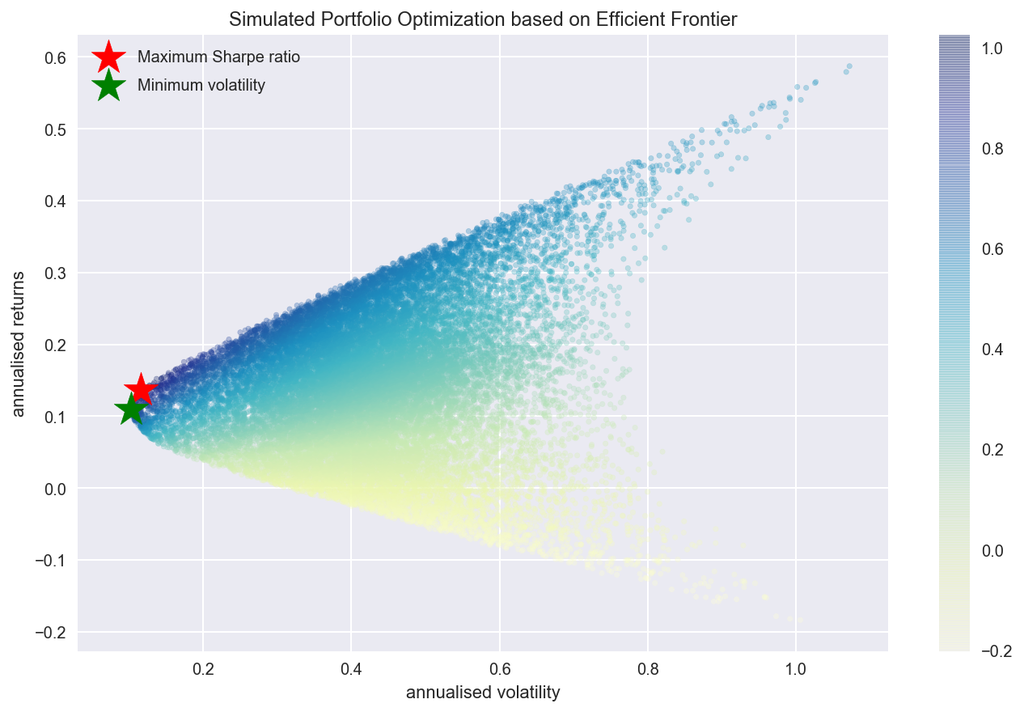

```python
display_simulated_ef_with_random(mean_returns, cov_matrix, num_portfolios, risk_free_rate)
```

## Efficient Frontier

Line called efficient frontier: can be seen from the plot of the randomly simulated portfolio, it forms a shape of an arch line on the top of clustered blue dots.

Why is it efficient?

- Because points along the line will give the lowest risk for a given target return.
- All the other dots right to the line will give higher risk with same returns.

If the expected returns are the same, why would you take an extra risk when there's an option with lower risk?

The way we found the two kinds of optimal portfolio above was by:

- simulating many possible random choices
- pick the best ones (either minimum risk or maximum risk-adjusted return)

This can also be implemented by using Scipy's optimize function. Scipy's optimize function is doing the similar task to solver in excel when given what to optimize, and what are constraints and bounds.

Below functions are to get the maximum Sharpe ratio portfolio:

- In Scipy's optimize function, there's no 'maximize', so as an objective function you need to pass something that should be minimized.
  - That is why the first "neg_sharpe_ratio" is computing the negative Sharpe ratio. Now we can use this as our objective function to minimize.
  - In "max_sharpe_ratio" function, you first define arguments (this should not include the variables you would like to change for optimisation, in this case, "weights").

constraints = ({'type': 'eq', 'fun': lambda x: np.sum(x) - 1})

The above constraint is saying that sum of x should be equal to 1. You can think of the 'fun' part construction as '1' on the right side of equal sign has been moved to the left side of the equal sign.

'np.sum(x) == 1' has become 'np.sum(x)-1'

And what does this mean? It simply means that the sum of all the weights should be equal to 1. You cannot allocate more than 100% of your budget in total.

"bounds" is giving another limit to assign random weights, by saying any weight should be inclusively between 0 and 1. You cannot give minus budget allocation to a stock or more than 100% allocation to a stock.

```python
def neg_sharpe_ratio(weights, mean_returns, cov_matrix, risk_free_rate):
    p_var, p_ret = portfolio_annualised_performance(weights, mean_returns, cov_matrix)
    return -(p_ret - risk_free_rate) / p_var

def max_sharpe_ratio(mean_returns, cov_matrix, risk_free_rate):
    num_assets = len(mean_returns)
    args = (mean_returns, cov_matrix, risk_free_rate)
    constraints = ({'type': 'eq', 'fun': lambda x: np.sum(x) - 1})
    bound = (0.0,1.0)
    bounds = tuple(bound for asset in range(num_assets))
    result = sco.minimize(neg_sharpe_ratio, num_assets*[1./num_assets,], args=args,
                        method='SLSQP', bounds=bounds, constraints=constraints)
    return result
```

We can also define the optimizing function for calculating minimum volatility portfolio. This time we really do minimize the objective function. What do we want to minimize? We want to minimize volatility by trying different weights. "constraints" and "bounds" are same as the above.

```python
def portfolio_volatility(weights, mean_returns, cov_matrix):
    return portfolio_annualised_performance(weights, mean_returns, cov_matrix)[0]

def min_variance(mean_returns, cov_matrix):
    num_assets = len(mean_returns)
    args = (mean_returns, cov_matrix)
    constraints = ({'type': 'eq', 'fun': lambda x: np.sum(x) - 1})
    bound = (0.0,1.0)
    bounds = tuple(bound for asset in range(num_assets))

    result = sco.minimize(portfolio_volatility, num_assets*[1./num_assets,], args=args,
                        method='SLSQP', bounds=bounds, constraints=constraints)

    return result
```

As I already mentioned above we can also draw a line which depicts where the efficient portfolios for a given risk rate should be. This is called "efficient frontier". Below I define other functions to compute efficient frontier. The first function "efficient_return" is calculating the most efficient portfolio for a given target return, and the second function "efficient_frontier" will take a range of target returns and compute efficient portfolio for each return level.

```python
def efficient_return(mean_returns, cov_matrix, target):
    num_assets = len(mean_returns)
    args = (mean_returns, cov_matrix)

    def portfolio_return(weights):
        return portfolio_annualised_performance(weights, mean_returns, cov_matrix)[1]

    constraints = ({'type': 'eq', 'fun': lambda x: portfolio_return(x) - target},
                   {'type': 'eq', 'fun': lambda x: np.sum(x) - 1})
    bounds = tuple((0,1) for asset in range(num_assets))
    result = sco.minimize(portfolio_volatility, num_assets*[1./num_assets,], args=args, method='SLSQP', bounds=bounds, constraints=constraints)
    return result


def efficient_frontier(mean_returns, cov_matrix, returns_range):
    efficients = []
    for ret in returns_range:
        efficients.append(efficient_return(mean_returns, cov_matrix, ret))
    return efficients
```

Let's try to plot the portfolio choice with maximum Sharpe ratio and minimum volatility also with all the randomly generated portfolios. But this time we are not picking the optimal ones from the randomly generated portfolios, but we are actually calculating by using Scipy's 'minimize' function. And the below function will also plot the efficient frontier line.

```python
def display_calculated_ef_with_random(mean_returns, cov_matrix, num_portfolios, risk_free_rate):
    results, _ = random_portfolios(num_portfolios,mean_returns, cov_matrix, risk_free_rate)

    max_sharpe = max_sharpe_ratio(mean_returns, cov_matrix, risk_free_rate)
    sdp, rp = portfolio_annualised_performance(max_sharpe['x'], mean_returns, cov_matrix)
    max_sharpe_allocation = pd.DataFrame(max_sharpe.x,index=df.columns,columns=['allocation'])
    max_sharpe_allocation.allocation = [round(i*100,2)for i in max_sharpe_allocation.allocation]
    max_sharpe_allocation = max_sharpe_allocation.T
    max_sharpe_allocation

    min_vol = min_variance(mean_returns, cov_matrix)
    sdp_min, rp_min = portfolio_annualised_performance(min_vol['x'], mean_returns, cov_matrix)
    min_vol_allocation = pd.DataFrame(min_vol.x,index=df.columns,columns=['allocation'])
    min_vol_allocation.allocation = [round(i*100,2)for i in min_vol_allocation.allocation]
    min_vol_allocation = min_vol_allocation.T

    print("-"*80)
    print("Maximum Sharpe Ratio Portfolio Allocation\n")
    print("Annualised Return:", round(rp,2))
    print("Annualised Volatility:", round(sdp,2))
    print("\n")
    print(max_sharpe_allocation)
    print("-"*80)
    print("Minimum Volatility Portfolio Allocation\n")
    print("Annualised Return:", round(rp_min,2))
    print("Annualised Volatility:", round(sdp_min,2))
    print("\n")
    print(min_vol_allocation)

    plt.figure(figsize=(10, 7))
    plt.scatter(results[0,:],results[1,:],c=results[2,:],cmap='YlGnBu', marker='o', s=10, alpha=0.3)
    plt.colorbar()
    plt.scatter(sdp,rp,marker='*',color='r',s=500, label='Maximum Sharpe ratio')
    plt.scatter(sdp_min,rp_min,marker='*',color='g',s=500, label='Minimum volatility')

    target = np.linspace(rp_min, 0.32, 50)
    efficient_portfolios = efficient_frontier(mean_returns, cov_matrix, target)
    plt.plot([p['fun'] for p in efficient_portfolios], target, linestyle='-.', color='black', label='efficient frontier')
    plt.title('Calculated Portfolio Optimization based on Efficient Frontier')
    plt.xlabel('annualised volatility')
    plt.ylabel('annualised returns')
    plt.legend(labelspacing=0.8)
```

```
--------------------------------------------------------------------------------
Maximum Sharpe Ratio Portfolio Allocation

Annualised Return: 0.14
Annualised Volatility: 0.11


             ES=F  CL=F   ^VIX   GC=F
allocation  62.31   0.0  11.28  26.42
--------------------------------------------------------------------------------
Minimum Volatility Portfolio Allocation

Annualised Return: 0.11
Annualised Volatility: 0.1


             ES=F  CL=F  ^VIX   GC=F
allocation  58.13   0.0  6.53  35.34
```

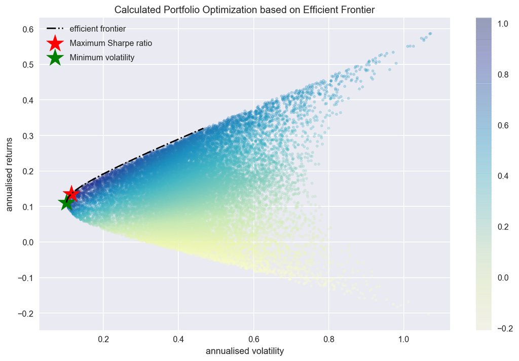

```python
display_calculated_ef_with_random(mean_returns, cov_matrix, num_portfolios, risk_free_rate)
```

We have almost the same result as what we have simulated by picking from the randomly generated portfolios. The slight difference is that the Scipy's "optimize" function has not allocated any budget at all for CL. There are some differences in the decimal places but more or less same.

Instead of plotting every randomly generated portfolio, we can plot each individual asset on the plot with the corresponding values of each asset's annual return and annual risk. This way we can see and compare how diversification is lowering the risk by optimising the allocation.

```python
def display_ef_with_selected(mean_returns, cov_matrix, risk_free_rate):
    max_sharpe = max_sharpe_ratio(mean_returns, cov_matrix, risk_free_rate)
    sdp, rp = portfolio_annualised_performance(max_sharpe['x'], mean_returns, cov_matrix)
    max_sharpe_allocation = pd.DataFrame(max_sharpe.x,index=df.columns,columns=['allocation'])
    max_sharpe_allocation.allocation = [round(i*100,2)for i in max_sharpe_allocation.allocation]
    max_sharpe_allocation = max_sharpe_allocation.T
    max_sharpe_allocation

    min_vol = min_variance(mean_returns, cov_matrix)
    sdp_min, rp_min = portfolio_annualised_performance(min_vol['x'], mean_returns, cov_matrix)
    min_vol_allocation = pd.DataFrame(min_vol.x,index=df.columns,columns=['allocation'])
    min_vol_allocation.allocation = [round(i*100,2)for i in min_vol_allocation.allocation]
    min_vol_allocation = min_vol_allocation.T

    an_vol = np.std(returns) * np.sqrt(252)
    an_rt = mean_returns * 252

    print("-"*80)
    print("Maximum Sharpe Ratio Portfolio Allocation\n")
    print("Annualised Return:", round(rp,2))
    print("Annualised Volatility:", round(sdp,2))
    print("\n")
    print(max_sharpe_allocation)
    print("-"*80)
    print("Minimum Volatility Portfolio Allocation\n")
    print("Annualised Return:", round(rp_min,2))
    print("Annualised Volatility:", round(sdp_min,2))
    print("\n")
    print(min_vol_allocation)
    print("-"*80)
    print("Individual Stock Returns and Volatility\n")
    for i, txt in enumerate(df.columns):
        print(txt,":","annuaised return",round(an_rt[i],2),", annualised volatility:",round(an_vol[i],2))
    print("-"*80)

    fig, ax = plt.subplots(figsize=(10, 7))
    ax.scatter(an_vol,an_rt,marker='o',s=200)

    for i, txt in enumerate(df.columns):
        ax.annotate(txt, (an_vol[i],an_rt[i]), xytext=(10,0), textcoords='offset points')
    ax.scatter(sdp,rp,marker='*',color='r',s=500, label='Maximum Sharpe ratio')
    ax.scatter(sdp_min,rp_min,marker='*',color='g',s=500, label='Minimum volatility')

    target = np.linspace(rp_min, 0.34, 50)
    efficient_portfolios = efficient_frontier(mean_returns, cov_matrix, target)
    ax.plot([p['fun'] for p in efficient_portfolios], target, linestyle='-.', color='black', label='efficient frontier')
    ax.set_title('Portfolio Optimization with Individual Stocks')
    ax.set_xlabel('annualised volatility')
    ax.set_ylabel('annualised returns')
    ax.legend(labelspacing=0.8)
```

```
--------------------------------------------------------------------------------
Maximum Sharpe Ratio Portfolio Allocation

Annualised Return: 0.14
Annualised Volatility: 0.11


             ES=F  CL=F   ^VIX   GC=F
allocation  62.36   0.0  11.29  26.35
--------------------------------------------------------------------------------
Minimum Volatility Portfolio Allocation

Annualised Return: 0.11
Annualised Volatility: 0.1


             ES=F  CL=F  ^VIX  GC=F
allocation  58.15   0.0  6.55  35.3
--------------------------------------------------------------------------------
Individual Stock Returns and Volatility

ES=F : annuaised return 0.07 , annualised volatility: 0.18
CL=F : annuaised return -0.22 , annualised volatility: 1.13
^VIX : annuaised return 0.63 , annualised volatility: 1.16
GC=F : annuaised return 0.09 , annualised volatility: 0.17
--------------------------------------------------------------------------------
```

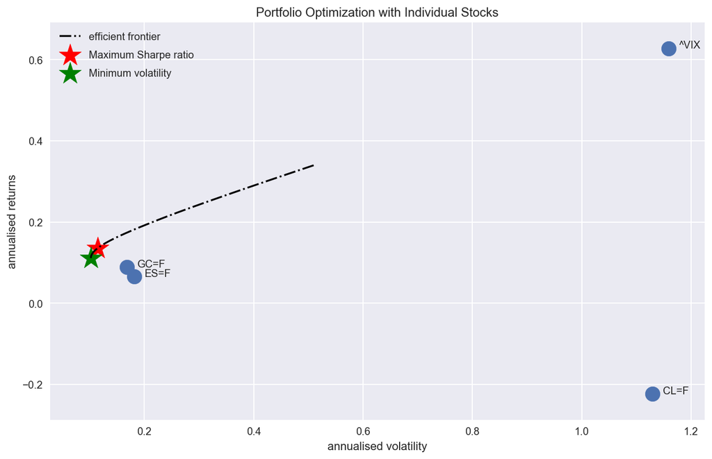

```python
display_ef_with_selected(mean_returns, cov_matrix, risk_free_rate)
```

# Build a Portfolio

## Equal Weight Portfolio

```python
equal_weight_portfolio = (1+((returns).mean(axis=1))).cumprod()
equal_weight_portfolio.head()
```

```
2005-04-25         NaN
2005-04-26    1.002961
2005-04-27    0.988261
2005-04-28    1.019049
2005-04-29    0.990171
dtype: float64
```

### Portfolio Returns

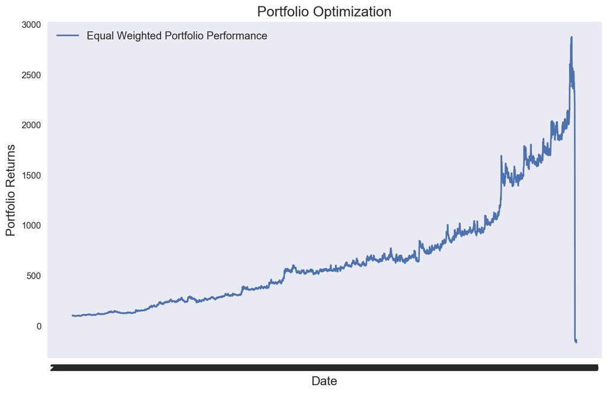

```python
# Plot the percentage returns of Kelly and Equal Weight portfolios
plt.figure(figsize=(10, 7))
plt.plot(equal_weight_portfolio*100, label='Equal Weighted Portfolio Performance')


plt.xlabel('Date', fontsize=14)
plt.ylabel('Portfolio Returns', fontsize=14)
plt.legend(loc='best', fontsize=12)
plt.title('Portfolio Optimization', fontsize=16)
plt.legend(loc='best', fontsize=12)
plt.grid()
plt.show()
```

## Max Sharpe Portfolio

```python
max_sharpe = max_sharpe_ratio(mean_returns, cov_matrix, risk_free_rate)
sdp, rp = portfolio_annualised_performance(max_sharpe['x'], mean_returns, cov_matrix)
max_sharpe_allocation = pd.DataFrame(max_sharpe.x,index=df.columns,columns=['allocation'])
max_sharpe_allocation
```

|  | allocation |
| --- | --- |
| ES=F | 6.235937e-01 |
| CL=F | 1.041808e-15 |
| ^VIX | 1.128811e-01 |
| GC=F | 2.635252e-01 |

```python
max_sharpe_portfolio = (1+((returns)*(max_sharpe_allocation.allocation)).sum(axis=1)).cumprod()
max_sharpe_portfolio.head()
```

```
2005-04-25    1.000000
2005-04-26    0.998749
2005-04-27    0.997391
2005-04-28    1.004799
2005-04-29    1.004092
dtype: float64
```

### Risk Contribution

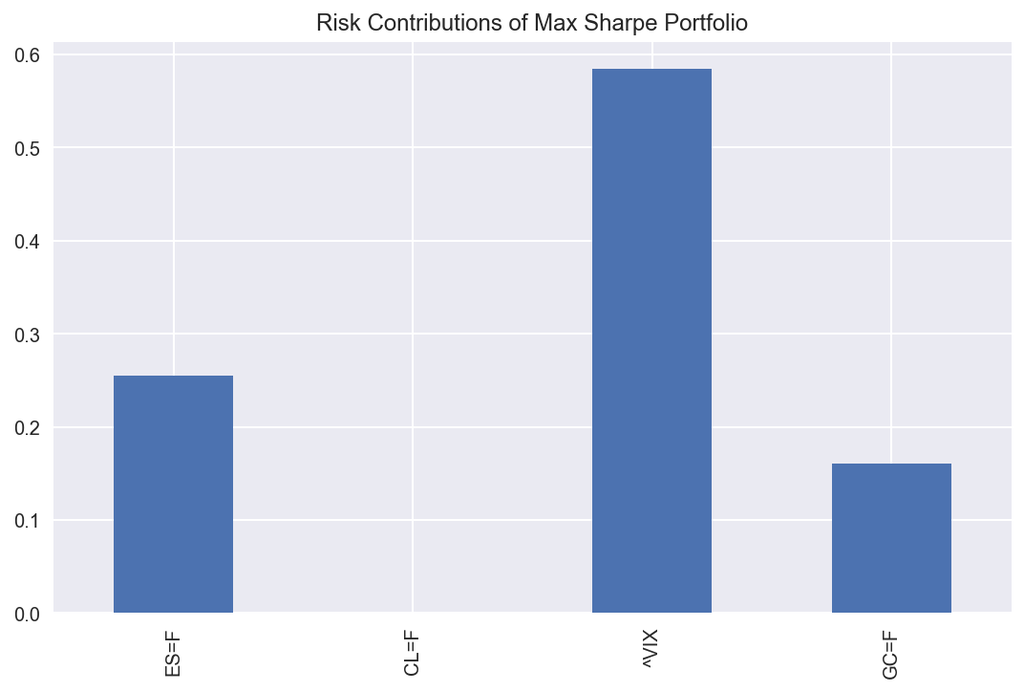

```python
risk_contribution(max_sharpe_allocation.allocation, cov_matrix).plot.bar(title="Risk Contributions of Max Sharpe Portfolio");
```

### Simulation of changes in the portfolio

```python
max_sharpe_allocation_simulation = max_sharpe_allocation
```

```python
weight0 = 0.05
weight1 = 0.05
weight2 = - 0.1
weight3 = 0
```

```python
max_sharpe_allocation_simulation.allocation[0] = max_sharpe_allocation_simulation.allocation[0] + weight0
max_sharpe_allocation_simulation.allocation[1] = max_sharpe_allocation_simulation.allocation[1] + weight1
max_sharpe_allocation_simulation.allocation[2] = max_sharpe_allocation_simulation.allocation[2] + weight2
max_sharpe_allocation_simulation.allocation[3] = max_sharpe_allocation_simulation.allocation[3] + weight3
max_sharpe_allocation_simulation
```

|  | allocation |
| --- | --- |
| ES=F | 0.673594 |
| CL=F | 0.050000 |
| ^VIX | 0.012881 |
| GC=F | 0.263525 |

```python
max_sharpe_portfolio_simulation = (1+((returns)*(max_sharpe_allocation.allocation)).sum(axis=1)).cumprod()
max_sharpe_portfolio_simulation.head()
```

```
2005-04-25    1.000000
2005-04-26    0.995986
2005-04-27    0.992670
2005-04-28    0.986302
2005-04-29    0.993391
dtype: float64
```

#### Risk Contribution

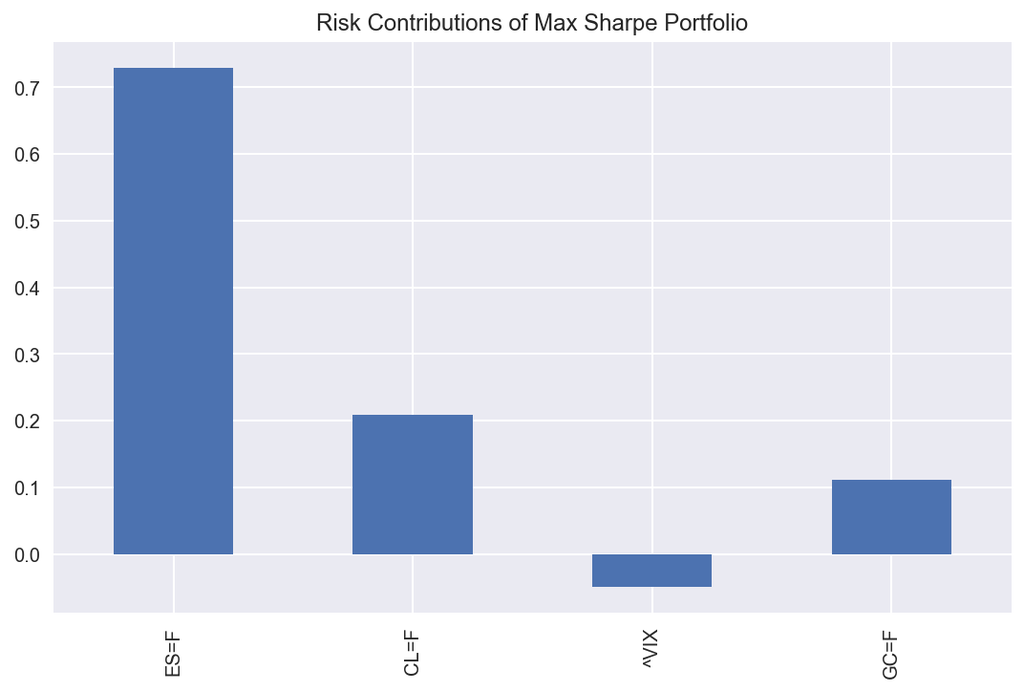

```python
risk_contribution(max_sharpe_allocation_simulation.allocation, cov_matrix).plot.bar(title="Risk Contributions of Max Sharpe Portfolio");
```

#### Portfolio Returns

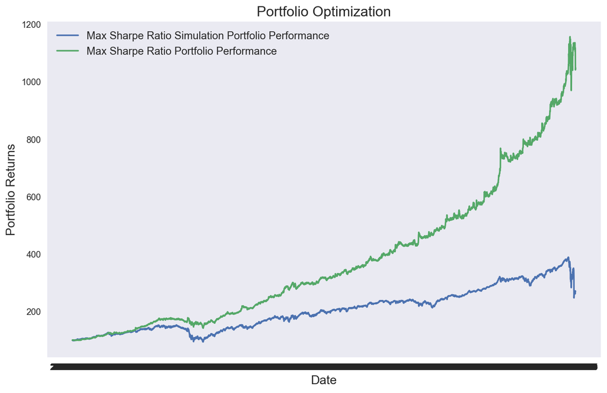

```python
# Plot the percentage returns of Kelly and Equal Weight portfolios
plt.figure(figsize=(10, 7))
plt.plot(max_sharpe_portfolio_simulation*100, label='Max Sharpe Ratio Simulation Portfolio Performance')
plt.plot(max_sharpe_portfolio*100, label='Max Sharpe Ratio Portfolio Performance')


plt.xlabel('Date', fontsize=14)
plt.ylabel('Portfolio Returns', fontsize=14)
plt.legend(loc='best', fontsize=12)
plt.title('Portfolio Optimization', fontsize=16)
plt.legend(loc='best', fontsize=12)
plt.grid()
plt.show()
```

## Min Variance Portfolio

```python
min_vol = min_variance(mean_returns, cov_matrix)
sdp_min, rp_min = portfolio_annualised_performance(min_vol['x'], mean_returns, cov_matrix)
min_vol_allocation = pd.DataFrame(min_vol.x,index=df.columns,columns=['allocation'])
min_vol_allocation.allocation = [round(i*100,2)for i in min_vol_allocation.allocation]
min_vol_allocation
```

|  | allocation |
| --- | --- |
| ES=F | 58.15 |
| CL=F | 0.00 |
| ^VIX | 6.55 |
| GC=F | 35.30 |

```python
min_var_portfolio = (1+((returns)*(min_vol_allocation.allocation)).sum(axis=1)).cumprod()
min_var_portfolio.tail()
```

```
2020-05-03   -2.699264e-92
2020-05-04   -4.384615e-92
2020-05-05   -7.608165e-92
2016-10-10    2.238682e-91
2016-11-11    3.104456e-91
dtype: float64
```

### Risk Contribution

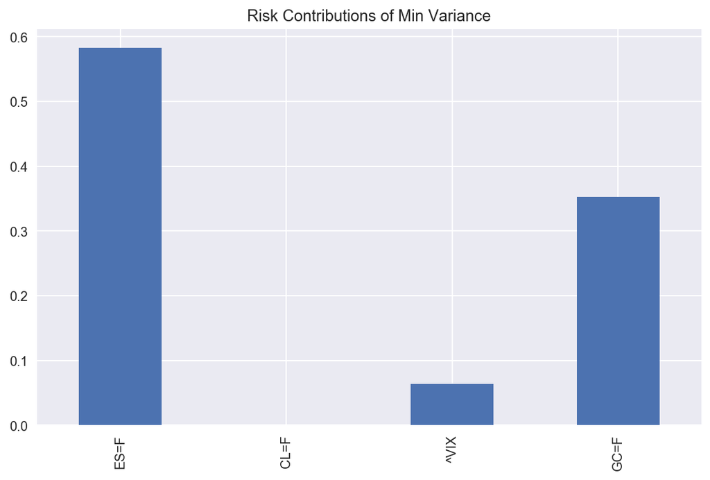

```python
risk_contribution(min_vol_allocation.allocation, cov_matrix).plot.bar(title="Risk Contributions of Min Variance");
```

### Portfolio Returns

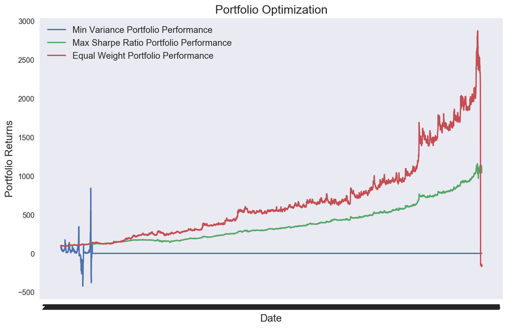

```python
plt.figure(figsize=(10, 7))
plt.plot(min_var_portfolio*100, label='Min Variance Portfolio Performance')
plt.plot(max_sharpe_portfolio*100, label='Max Sharpe Ratio Portfolio Performance')
plt.plot(equal_weight_portfolio*100, label='Equal Weight Portfolio Performance')

plt.xlabel('Date', fontsize=14)
plt.ylabel('Portfolio Returns', fontsize=14)
plt.legend(loc='best', fontsize=12)
plt.title('Portfolio Optimization', fontsize=16)
plt.legend(loc='best', fontsize=12)
plt.grid()
plt.show()
```

## Risk Parity Portfolio

```python
from scipy.optimize import minimize

def target_risk_contributions(target_risk, cov):
    """
    Returns the weights of the portfolio that gives you the weights such
    that the contributions to portfolio risk are as close as possible to
    the target_risk, given the covariance matrix
    """
    n = cov.shape[0]
    init_guess = np.repeat(1/n, n)
    bounds = ((0.0, 1.0),) * n # an N-tuple of 2-tuples!
    # construct the constraints
    weights_sum_to_1 = {'type': 'eq',
                        'fun': lambda weights: np.sum(weights) - 1
    }
    def msd_risk(weights, target_risk, cov):
        """
        Returns the Mean Squared Difference in risk contributions
        between weights and target_risk
        """
        w_contribs = risk_contribution(weights, cov)
        return ((w_contribs-target_risk)**2).sum()

    weights = minimize(msd_risk, init_guess,
                       args=(target_risk, cov), method='Powell',
                       options={'disp': False},
                       constraints=(weights_sum_to_1,),
                       bounds=bounds)
    return weights.x


def equal_risk_contributions(cov):
    """
    Returns the weights of the portfolio that equalizes the contributions
    of the constituents based on the given covariance matrix
    """
    n = cov.shape[0]
    return target_risk_contributions(target_risk=np.repeat(1/n,n), cov=cov)
```

```python
def msd_risk(weights, target_risk, cov):
        """
        Returns the Mean Squared Difference in risk contributions
        between weights and target_risk
        """
        w_contribs = risk_contribution(weights, cov)
        return ((w_contribs-target_risk)**2).sum()

n = cov_matrix.shape[0]
target_risk = np.repeat(1/n,n)


init_guess = np.repeat(1/n, n)
bounds = ((0.0, 1.0),) * n # an N-tuple of 2-tuples!
# construct the constraints
weights_sum_to_1 = {'type': 'eq',
                    'fun': lambda weights: np.sum(weights) - 1}


weights = minimize(msd_risk, init_guess,
                   args=(target_risk, cov_matrix), method='Powell', # POWEL!!!!!!
                   options={'disp': False},
                   constraints=(weights_sum_to_1,),
                   bounds=bounds)
```

```python
equal_risk_contributions(cov_matrix)
```

```
array([1.6273817 , 0.15357485, 0.26982202, 1.05679015])
```

```python
min_vol_allocation.allocation
```

[output not shown]

### Risk Contribution

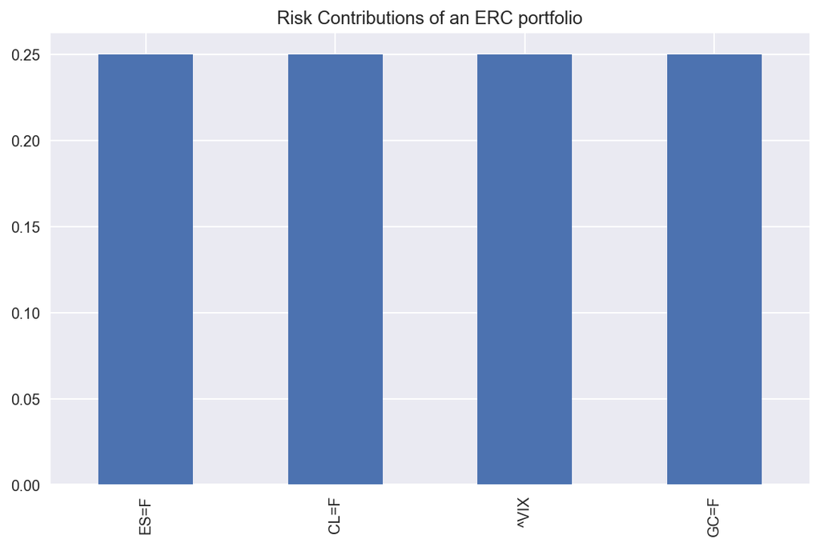

```python
risk_contribution(equal_risk_contributions(cov_matrix), cov_matrix).plot.bar(title="Risk Contributions of an ERC portfolio");
```

### Portfolio Returns

```python
risk_par_portfolio = (1+((returns)*(equal_risk_contributions(cov_matrix))).sum(axis=1)).cumprod()
risk_par_portfolio.tail()
```

```
2020-05-03    106.218478
2020-05-04    108.775027
2020-05-05    115.520715
2016-10-10     96.759341
2016-11-11     98.300833
dtype: float64
```

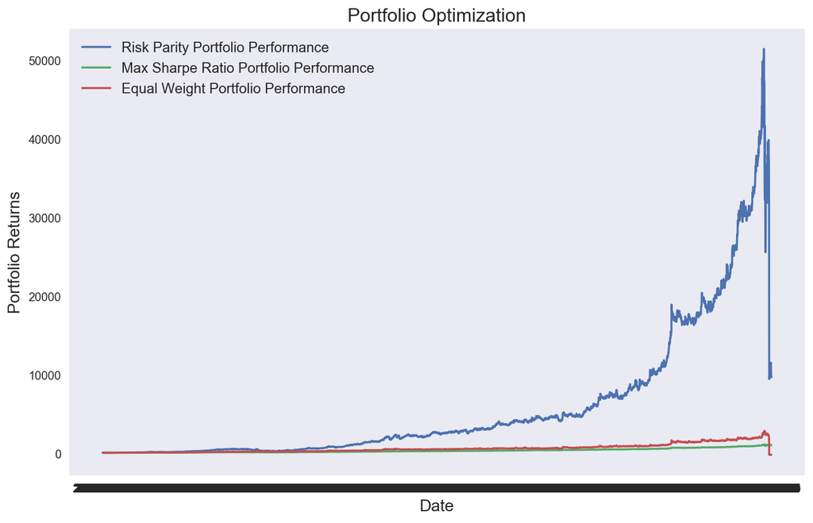

```python
# Plot the percentage returns of Kelly and Equal Weight portfolios
plt.figure(figsize=(10, 7))
plt.plot(risk_par_portfolio*100, label='Risk Parity Portfolio Performance')
plt.plot(max_sharpe_portfolio*100, label='Max Sharpe Ratio Portfolio Performance')
plt.plot(equal_weight_portfolio*100, label='Equal Weight Portfolio Performance')

plt.xlabel('Date', fontsize=14)
plt.ylabel('Portfolio Returns', fontsize=14)
plt.legend(loc='best', fontsize=12)

plt.title('Portfolio Optimization', fontsize=16)
plt.legend(loc='best', fontsize=12)
plt.grid()
plt.show()
```

## Beta Neutral portfolios

### Asset VS Benchmark

```python
# CHOOSE ASSETS
assets = ['SPY', 'TSLA']
yahoo_financials = YahooFinancials(assets)
# ADJUST DATE
data = yahoo_financials.get_historical_price_data(start_date='2011-01-01',
                                                  end_date='2020-05-06',
                                                  time_interval='DAILY')

prices_df = pd.DataFrame({
    a: {x['formatted_date']: x['adjclose'] for x in data[a]['prices']} for a in assets
})
```

```python
# prices_df = prices_df.dropna(thresh=1)
```

```python
df = prices_df
df.tail()
```

|  | SPY | TSLA |
| --- | --- | --- |
| 2020-04-29 | 293.209991 | 800.510010 |
| 2020-04-30 | 290.480011 | 781.880005 |
| 2020-05-01 | 282.790009 | 701.320007 |
| 2020-05-04 | 283.570007 | 761.190002 |
| 2020-05-05 | 286.190002 | 768.210022 |

#### Visualization

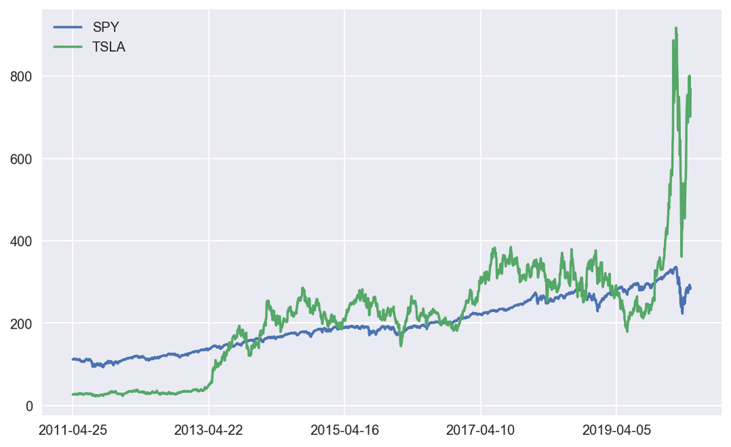

```python
df.plot()
```

#### Returns

```python
returns = df.pct_change()
```

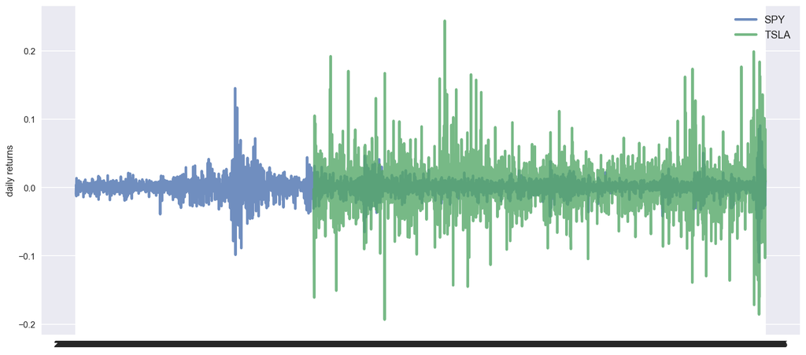

```python
plt.figure(figsize=(14, 7))
for c in returns.columns.values:
    plt.plot(returns.index, returns[c], lw=3, alpha=0.8,label=c)
plt.legend(loc='upper right', fontsize=12)
plt.ylabel('daily returns')
```

Volatility, positive and negative spike returns can be seen in this plot.

```python
lookback = 21*6
corr_lookback = 21*24
periodicity = 252
```

```python
returns
```

|  | SPY | TSLA |
| --- | --- | --- |
| 2011-04-25 | NaN | NaN |
| 2011-04-26 | 0.008605 | 0.020462 |
| 2011-04-27 | 0.006529 | 0.005570 |
| 2011-04-28 | 0.003243 | 0.021418 |
| 2011-04-29 | 0.002351 | -0.002169 |
| ... | ... | ... |
| 2020-04-29 | 0.026178 | 0.040813 |
| 2020-04-30 | -0.009311 | -0.023273 |
| 2020-05-01 | -0.026473 | -0.103034 |
| 2020-05-04 | 0.002758 | 0.085368 |
| 2020-05-05 | 0.009239 | 0.009222 |

2273 rows × 2 columns

```python
returnsTable = returns
```

```python
returnsTable.index = pd.to_datetime(returnsTable.index)
```

```python
to_summary(returnsTable)
```

|  | SPY | TSLA |
| --- | --- | --- |
| Summary Stats: |  |  |
| Annualized Return | 11.03% | 45.32% |
| Sharpe | 0.64 | 0.84 |
| Volatility | 0.17 | 0.54 |
| VaR | 0.05% | 0.17% |
| Sortino | 0.97 | 1.47 |
| Max Drawdown | -33.72% | -60.63% |
| Monthly Perf. Metrics: |  |  |
| Sharpe | 0.82 | 0.79 |
| Sortino | 1.42 | 2.15 |
| Calmar | 0.41 | 0.64 |
| Annual Returns: |  |  |
| 2011 | -4.54% | 8.22% |
| 2012 | 15.99% | 18.59% |
| 2013 | 32.31% | 344.14% |
| 2014 | 13.46% | 47.85% |
| 2015 | 1.23% | 7.91% |
| 2016 | 12.00% | -10.97% |
| 2017 | 21.71% | 45.70% |
| 2018 | -4.57% | 6.89% |
| 2019 | 31.22% | 25.70% |
| 2020 | -10.56% | 83.64% |
| Annual Max DD: |  |  |
| 2011 | -18.61% | -27.17% |
| 2012 | -9.69% | -31.33% |
| 2013 | -5.55% | -37.68% |
| 2014 | -7.27% | -30.85% |
| 2015 | -11.91% | -26.69% |
| 2016 | -9.19% | -35.70% |
| 2017 | -2.61% | -22.27% |
| 2018 | -19.35% | -33.99% |
| 2019 | -6.62% | -48.47% |
| 2020 | -33.72% | -60.63% |

#### Alpha and Beta

```python
# Let's define everything in familiar regression terms
X = df.TSLA.values # Get just the values, ignore the timestamps
Y = df.SPY.values

def linreg(x,y):
    # We add a constant so that we can also fit an intercept (alpha) to the model
    # This just adds a column of 1s to our data
    x = sm.add_constant(x)
    model = regression.linear_model.OLS(y,x).fit()
    # Remove the constant now that we're done
    x = x[:, 1]
    return model.params[0], model.params[1]

alpha, beta = linreg(X,Y)
print('alpha: ' + str(alpha))
print('beta: ' + str(beta))
```

```
alpha: 116.49930634893867
beta: 0.3704549019985359
```

If we plot the line $\alpha + \beta X$, we can see that it does indeed look like the line of best fit:

[figure not shown]

```python
X2 = np.linspace(X.min(), X.max(), 100)
Y_hat = X2 * beta + alpha

plt.scatter(X, Y, alpha=0.3) # Plot the raw data
plt.xlabel("SPY Daily Return")
plt.ylabel("TSLA Daily Return")

 # Add the regression line, colored in red
plt.plot(X2, Y_hat, 'r', alpha=0.9);
```

#### Implementing hedging

Now that we know how much to hedge, let's see how it affects our returns. We will build our portfolio using the asset and the benchmark, weighing the benchmark by $-\beta$ (negative since we are short in it).

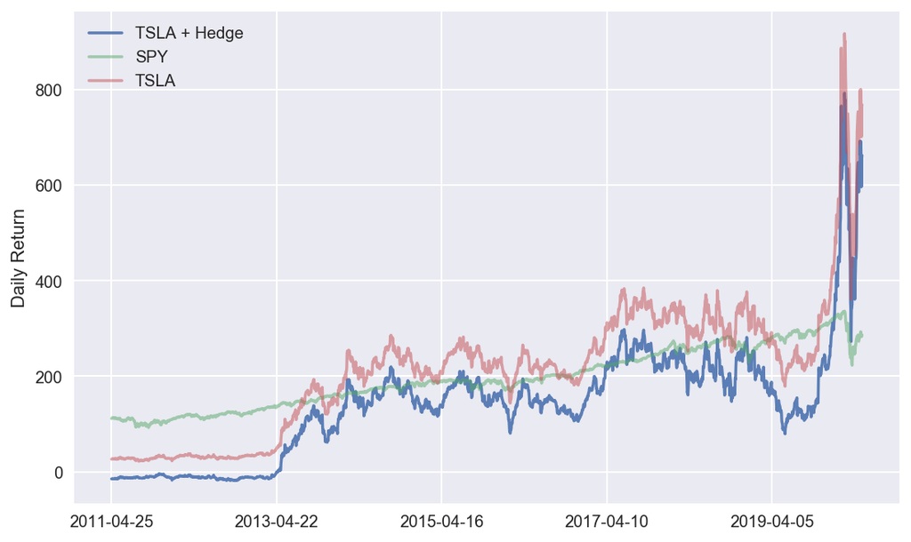

```python
# Construct a portfolio with beta hedging
portfolio = -1*beta*df.SPY + df.TSLA
portfolio.name = "TSLA + Hedge"

# Plot the returns of the portfolio as well as the asset by itself
portfolio.plot(alpha=0.9)
df.SPY.plot(alpha=0.5);
df.TSLA.plot(alpha=0.5);
plt.ylabel("Daily Return")
plt.legend();
```

It looks like the portfolio return follows the asset alone fairly closely. We can quantify the difference in their performances by computing the mean returns and the volatilities (standard deviations of returns) for both:

```python
print("means: ", portfolio.mean(), df.TSLA.mean()
print("volatilities: ", portfolio.std(), df.TSLA.std()
```

[output not shown]

We've decreased volatility at the expense of some returns. Let's check that the alpha is the same as before, while the beta has been eliminated:

```python
P = portfolio.values
alpha, beta = linreg(X,P)
print('alpha: ' + str(alpha)
print('beta: ' + str(beta)
```

[output not shown]

Note that we developed our hedging strategy using historical data. We can check that it is still valid out of sample by checking the alpha and beta values of the asset and the hedged portfolio in a different time frame:

```
Asset Historical Estimate:
alpha: 0.0003476231061617983
beta: 0.10773847008147643
Asset Out of Sample Estimate:
alpha: -0.0030324342830056064
beta: 0.23824570854582863
Portfolio Out of Sample:
alpha: 0.000326709830273649
beta: 0.9743317718577951
```

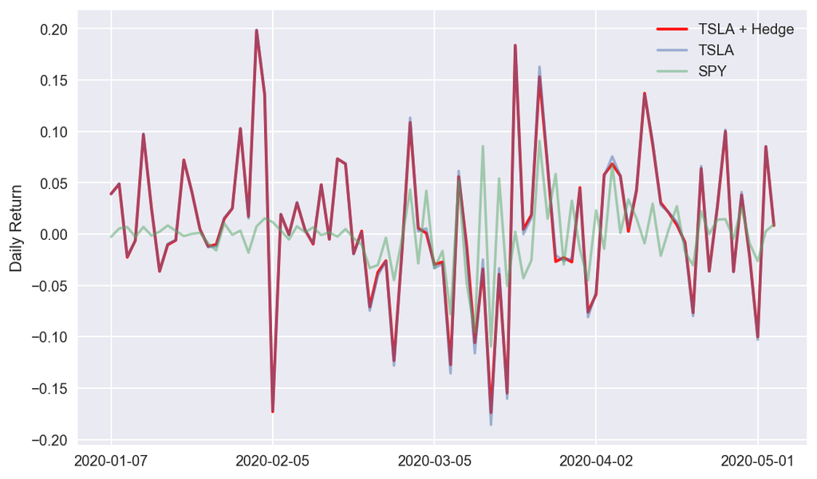

```python
# Get the alpha and beta estimates over the last year
start = '2011-01-04'
end = '2020-01-01'

# Data download###################################
# CHOOSE ASSETS
assets = ['SPY', 'TSLA']
yahoo_financials = YahooFinancials(assets)
# ADJUST DATE
data = yahoo_financials.get_historical_price_data(start_date= start,
                                                  end_date=end,
                                                  time_interval='DAILY')

df = pd.DataFrame({
    a: {x['formatted_date']: x['adjclose'] for x in data[a]['prices']} for a in assets
})
df = df.pct_change()[1:]
X = df.TSLA.values # Get just the values, ignore the timestamps
Y = df.SPY.values
# Data download###################################




historical_alpha, historical_beta = linreg(X,Y)
print('Asset Historical Estimate:')
print('alpha: ' + str(historical_alpha))
print('beta: ' + str(historical_beta))

# Get data for a different time frame:
start = '2020-01-04'
end = '2020-05-06'

# Data download###################################
# CHOOSE ASSETS
assets = ['SPY', 'TSLA']
yahoo_financials = YahooFinancials(assets)
# ADJUST DATE
data = yahoo_financials.get_historical_price_data(start_date= start,
                                                  end_date=end,
                                                  time_interval='DAILY')

df = pd.DataFrame({
    a: {x['formatted_date']: x['adjclose'] for x in data[a]['prices']} for a in assets
})
df = df.pct_change()[1:]
X = df.TSLA.values # Get just the values, ignore the timestamps
Y = df.SPY.values
# Data download###################################

alpha, beta = linreg(X,Y)
print('Asset Out of Sample Estimate:')
print('alpha: ' + str(alpha))
print('beta: ' + str(beta))

# Create hedged portfolio and compute alpha and beta
portfolio = -1*historical_beta*df.SPY + df.TSLA
P = portfolio.values
alpha, beta = linreg(X,P)
print('Portfolio Out of Sample:')
print('alpha: ' + str(alpha))
print('beta: ' + str(beta))


# Plot the returns of the portfolio as well as the asset by itself
portfolio.name = "TSLA + Hedge"
portfolio.plot(alpha=0.9, linewidth=2, color = 'red')
df.TSLA.plot(alpha=0.5);
df.SPY.plot(alpha=0.5)
plt.ylabel("Daily Return")
plt.legend();
```

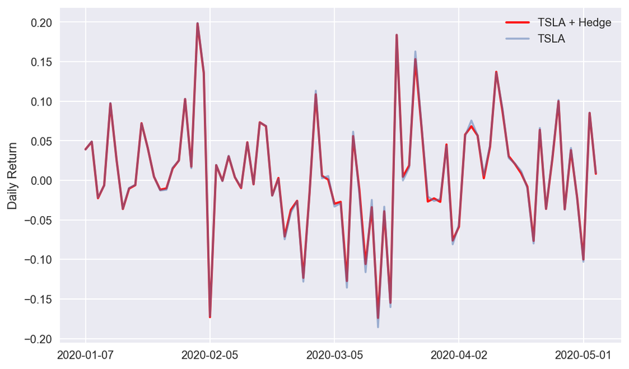

```python
# Plot the returns of the portfolio as well as the asset by itself
portfolio.name = "TSLA + Hedge"
portfolio.plot(alpha=0.9, linewidth=2, color = 'red')
df.TSLA.plot(alpha=0.5);
plt.ylabel("Daily Return")
plt.legend();
```

## Risk Exposure

More generally, this beta gets at the concept of how much risk exposure you take on by holding an asset. If an asset has a high beta exposure to the S&P 500, then while it will do very well while the market is rising, it will do very poorly when the market falls. A high beta corresponds to high speculative risk. You are taking out a more volatile bet.

Strategies with negligible beta exposure to as many factors as possible are very valued. What this means is that all of the returns in a strategy lie in the $\alpha$ portion of the model, and are independent of other factors. This is highly desirable, as it means that the strategy is agnostic to market conditions. It will make money equally well in a crash as it will during a bull market. These strategies are the most attractive to individuals with huge cash pools such as endowments and soverign wealth funds.

## Risk Management

The process of reducing exposure to other factors is known as risk management. Hedging is one of the best ways to perform risk management in practice.

### Hedging

If we determine that our portfolio's returns are dependent on the market via this relation

$$Y_{portfolio} = \alpha + \beta X_{SPY}$$

then we can take out a short position in SPY to try to cancel out this risk. The amount we take out is $-\beta V$ where $V$ is the total value of our portfolio. This works because if our returns are approximated by $\alpha + \beta X_{SPY}$, then adding a short in SPY will make our new returns be $\alpha + \beta X_{SPY} - \beta X_{SPY} = \alpha$. Our returns are now purely alpha, which is independent of SPY and will suffer no risk exposure to the market.

### Market Neutral

When a stragy exhibits a consistent beta of 0, we say that this strategy is market neutral.

### Problems with Estimation

The problem here is that the beta we estimated is not necessarily going to stay the same as we walk forward in time. As such the amount of short we took out in the SPY may not perfectly hedge our portfolio, and in practice it is quite difficult to reduce beta by a significant amount.

We will talk more about problems with estimating parameters in future lectures. In short, each estimate has a stardard error that corresponds with how stable the estimate is within the observed data.

# Bibliography

Series of Medium blog post by Bernard Brenyah (https://medium.com/@bbrenyah)

- Markowitz’s Efficient Frontier in Python [Part 1/2] (https://medium.com/python-data/effient-frontier-in-python-34b0c3043314)
- Markowitz’s Efficient Frontier in Python [Part 2/2] (https://medium.com/python-data/efficient-frontier-portfolio-optimization-with-python-part-2-2-2fe23413ad94)

Blog post by Bradford Lynch (http://www.bradfordlynch.com/)

- Investment Portfolio Optimization (http://www.bradfordlynch.com/blog/2015/12/04/InvestmentPortfolioOptimization.html)

The art of not following the market: https://www.youtube.com/watch?v=Af0l3TQJ3h8&feature=emb_title